# STAT545-hw-konecny-cassandra

Welcome to the repository of **Cassandra Konecny**. I am a first year MSc student in the department of zoology working with Dr. Christopher Harley. I am interested in how climate change (i.e. how changes in salinity, temperate, pH) influence species interactions and community composition. I am also an avid SCUBA diver and enjoy spending time in the ocean!

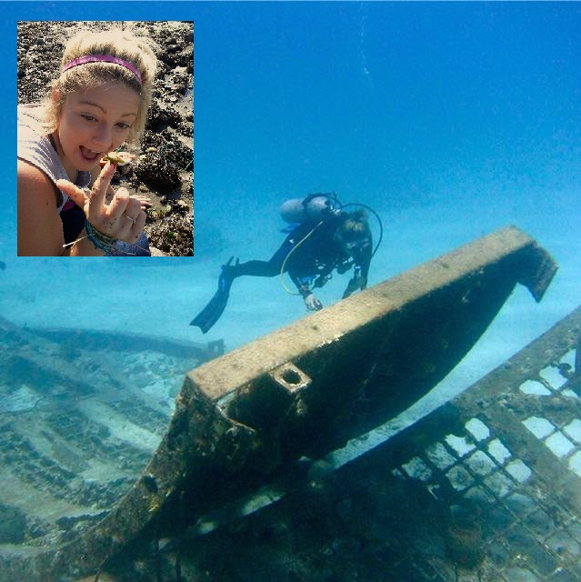

> “Every time I slip into the ocean, it’s like going home.” - Sylvia Earle

## Homework links:

[**Homework 01: Edit README.md and Use R Markdown**](https://github.com/CassKon/STAT545-hw-konecny-cassandra/tree/abe9b9e09d1049258ed481a859144ea36eded3ec/hw-1)

[**Homework 02: Explore Gapminder and use dplyr**](https://github.com/CassKon/STAT545-hw-konecny-cassandra/tree/abe9b9e09d1049258ed481a859144ea36eded3ec/hw-2)

## Process and Documentation

- I created a public repository on GitHub and initiated the readme file
- I originally edited the read me file on GitHub and added in my introduction text.
- I then used R studio to create a new project and make a copy of the repo on my local machine.
- I then made a series of modifications (added links, bold text, a quote and an image) by opening the readme .md file in RStudio. I used * the suggested workflow of pulling from GitHub, making changes, saving the changes, Committing the changes and then pushing them each time.
- I originally also added the homework link but then deleted it on GitHub as I decided to include it in the issue instead.

Overall, I feel like I now have a better understanding of the workflow outlined and how each step contributes to a better experience! It was a useful exercise to review working both on GitHub and locally.